# SEM diagnostic — sensitivity analysis

Author

Emma Belaud

# Overview

## Role in the pipeline

This script is the **second step** of the SEM pipeline, following:

1. `data_preparation.qmd` — assembles and quality-controls the SEM database

Its outputs feed directly into:

3. `3_SEM_modelisation.qmd` — full rolling-window piecewise SEM execution
4. `4_results_visualisation.qmd` — figure production and ecological interpretation

## What this script produces

| Output | File | Description |
| --- | --- | --- |
| Full benchmark table | `benchmark_results_database.csv` | Diagnostic statistics for every parameter combination × response variable |
| Selected parameters | `model_parameters.txt` | Optimal window, completeness threshold, and transformations (JSON) |
| Valid window list | `selected_windows.txt` | Dates of windows passing all diagnostic thresholds |
| Diagnostic figures | `Fig_diagnostics_*.tiff` | Six-panel residual check for each SEM equation under the selected configuration |

## Why run diagnostics before fitting the full SEM?

The full SEM is computationally expensive and requires several structural choices that cannot be validated after the fact without circularity. This script resolves three choices **before** the SEM is run:

**1. Window duration.** Rolling-window SEMs are fitted on short consecutive time slices to capture temporal variation in path strengths. The window must be long enough for stable LME estimation (enough observations for the random structure to converge) but short enough to track ecological dynamics within a season. We test 5, 7, 10, 14, and 21 days.

**2. Minimum data completeness.** Each window may have missing images (sensor downtime, quality control). A completeness threshold defines how much missingness is acceptable before a window is excluded. Too strict = too few windows for reliable temporal coverage; too lenient = noisy estimates from sparse data. We test 10 – 40%. Completeness is defined as `n_complete_rows / n_total_rows` — robust to unequal sampling across depths and variables (e.g. root growth recorded at only one depth while microclimate is at both).

**3. Variance-stabilising transformation.** Raw ecological counts (fauna, root growth) are right-skewed and have variance that scales with the mean. The LME residuals should be approximately normal with constant variance. We test five candidate transformations: none, square root, Freeman-Tukey (sqrt(x) + sqrt(x+1)), log(1+x), and Hellinger (sqrt(x / sum(x))). The transformation is applied uniformly to all modelled variables within each configuration.

## Statistical approach

At the diagnostic stage, each structural equation is fitted **independently as a classical LME** rather than within the full piecewise SEM.

The four structural equations are:

$$\text{microclimate}_1 \leftarrow \beta_1 \cdot \text{land\_use}$$
$$\text{microclimate}_2 \leftarrow \beta_2 \cdot \text{land\_use}$$
$$\text{Root} \leftarrow \beta_3 \cdot \text{mc}_1 + \beta_4 \cdot \text{mc}_2 + \beta_5 \cdot \text{lu}$$
$$\text{Fauna} \leftarrow \beta_6 \cdot \text{mc}_1 + \beta_7 \cdot \text{mc}_2 + \beta_8 \cdot \text{Root} + \beta_9 \cdot \text{lu}$$

Random structures differ by equation type because microclimate sensors have no orientation variable.

## Selection criterion

The optimal configuration is chosen by a **two-step procedure**:

**Step 1 — Per-response transformation selection:** For each response variable and each (window, min_rate) combination, find the transformation maximising `prop_valid_models × avg_R2_marginal`. This rewards configurations that are both diagnostically sound (high proportion of windows passing all thresholds) and explanatorily powerful (high R²m).

**Step 2 — Joint (window, min_rate) selection across biological responses:** Find the (window, min_rate) pair maximising `combined_validity × mean_R2`, where `combined_validity = min(prop_valid_root, prop_valid_fauna)`. The minimum rather than the mean is used deliberately: a configuration that works well for fauna but poorly for root would still be penalised, preventing one response from masking the other’s poor fit.

## Diagnostic thresholds

| Diagnostic | Metric | Threshold | Rationale |
| --- | --- | --- | --- |
| Heteroscedasticity | Spearman ρ(\|res\|, fitted) | < 0.4 | Monotone association between residual magnitude and fitted values indicates variance non-constancy |
| Skewness | \|skewness(normalised residuals)\| | < 1.5 | Departure from symmetry inflates Type I error for t-tests on fixed effects |
| Collinearity | max VIF across continuous predictors | < 5 | VIF > 5 inflates SE of individual path coefficients; `land_use` excluded as binary |
| Explanatory power | R²m, R²c | — | Reported for information; not used as a filter |

## 1. Setup

## 2. Functions

### 2.1 Rolling window splitter

### 2.2 Per-observation diagnostic extractor

### 2.3 Independent model fitting

### 2.4 Transformation functions

### 2.5 Main diagnostic pipeline

## 3. Benchmarking

### 3.1 Configuration tester

### 3.2 Sensitivity grid and execution

## 4. Results

### 4.1 Global optimisation

Top 5 configurations — ranked by joint validity then mean R² (lexicographic)

| Window (days) | Max missing data | Transfo root | Transfo fauna | Transfo microclimate 1 | Transfo microclimate 2 | Validity (joint) | R2 Marginal (mean) | Score |
| --- | --- | --- | --- | --- | --- | --- | --- | --- |
| 14 | 0.4 | log | log | hellinger | hellinger | 0.458 | 0.407 | 0.186 |
| 14 | 0.1 | log | sqrt_plus_one | none | log | 0.429 | 0.356 | 0.152 |
| 14 | 0.3 | log | sqrt_plus_one | none | none | 0.429 | 0.350 | 0.150 |
| 14 | 0.2 | log | sqrt | sqrt | hellinger | 0.327 | 0.394 | 0.129 |
| 21 | 0.2 | sqrt | hellinger | hellinger | log | 0.320 | 0.386 | 0.123 |

### 4.2 Per-equation summary — selected configuration

| Equation | Transform | Validity | R² marg. | R² cond. | ΔR² | Skewness | Heterosced. | VIF max |
| --- | --- | --- | --- | --- | --- | --- | --- | --- |
| Faunal activity | log | 0.960 | 0.402 | 0.495 | 0.093 | -0.355 | -0.100 | 1.97 |
| Root growth | log | 0.460 | 0.576 | 0.571 | -0.005 | 0.098 | -0.023 | 1.17 |
| temp_soil_max | hellinger | 0.458 | 0.509 | 0.509 | 0.000 | 0.360 | 0.054 | NaN |
| hum_soil_max | hellinger | 0.560 | 0.140 | 0.143 | 0.003 | 1.014 | -0.035 | NaN |

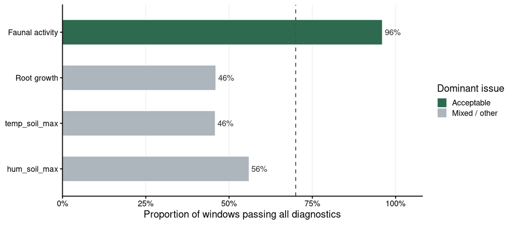

### 4.3 Window selection — retain only temporally stable windows

For each rolling window under the selected configuration, all four equations are fitted independently and the proportion passing all thresholds is computed. Only windows where **at least `MIN_VALID_PROP` of equations are valid** are retained for the downstream SEM execution in Script 3.

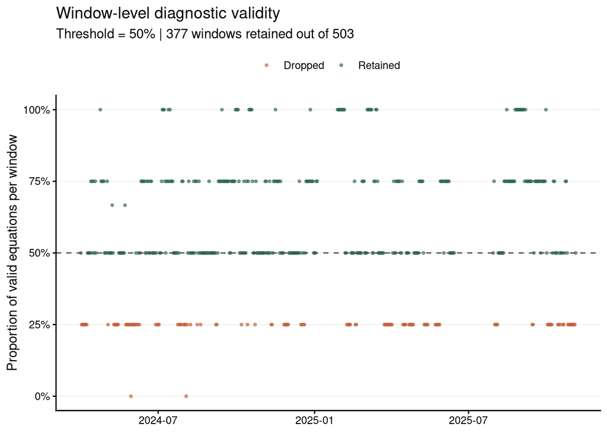

## 5. Visual diagnostics — selected configuration

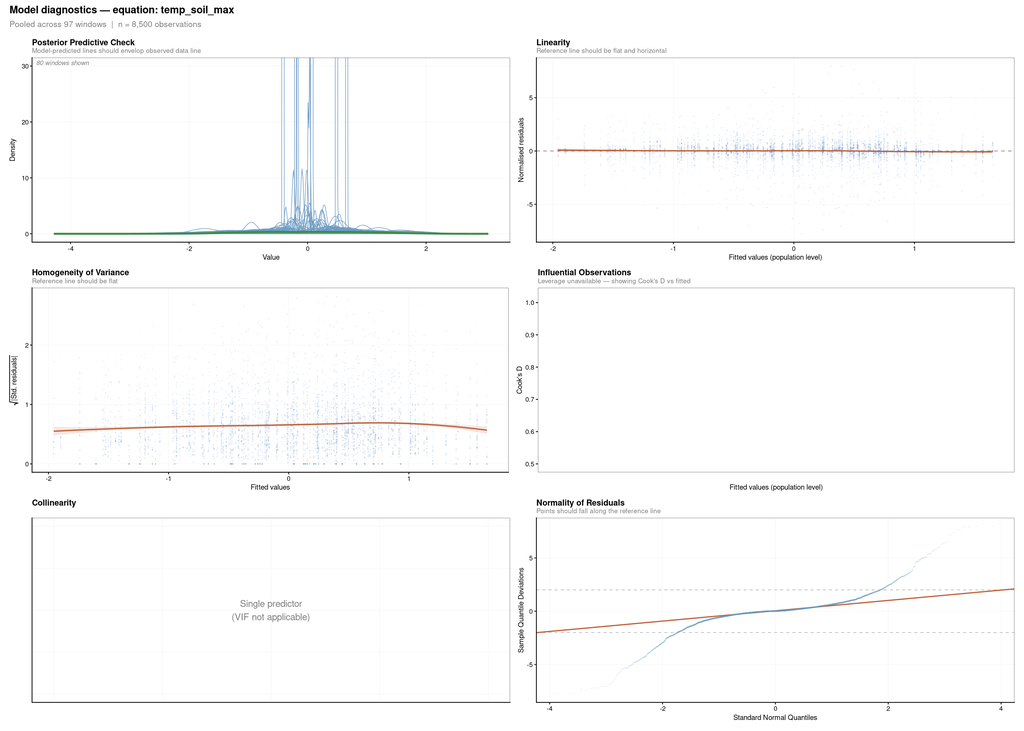

Figure 1: Six-panel model assumption diagnostics for each SEM equation under the selected configuration (window duration and transformation from model_parameters.txt, diagnostically valid windows only). Rows: P1-P2 (distributional fit and linearity), P3-P4 (variance homogeneity and influence), P5-P6 (collinearity and residual normality). See function documentation for panel-by-panel interpretation guidance.

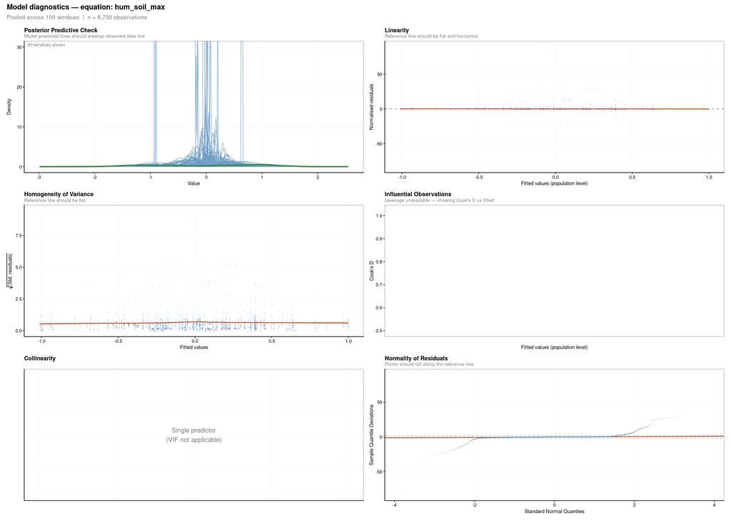

Figure 2: Six-panel model assumption diagnostics for each SEM equation under the selected configuration (window duration and transformation from model_parameters.txt, diagnostically valid windows only). Rows: P1-P2 (distributional fit and linearity), P3-P4 (variance homogeneity and influence), P5-P6 (collinearity and residual normality). See function documentation for panel-by-panel interpretation guidance.

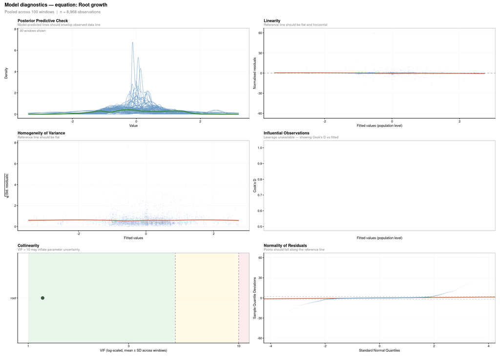

Figure 3: Six-panel model assumption diagnostics for each SEM equation under the selected configuration (window duration and transformation from model_parameters.txt, diagnostically valid windows only). Rows: P1-P2 (distributional fit and linearity), P3-P4 (variance homogeneity and influence), P5-P6 (collinearity and residual normality). See function documentation for panel-by-panel interpretation guidance.

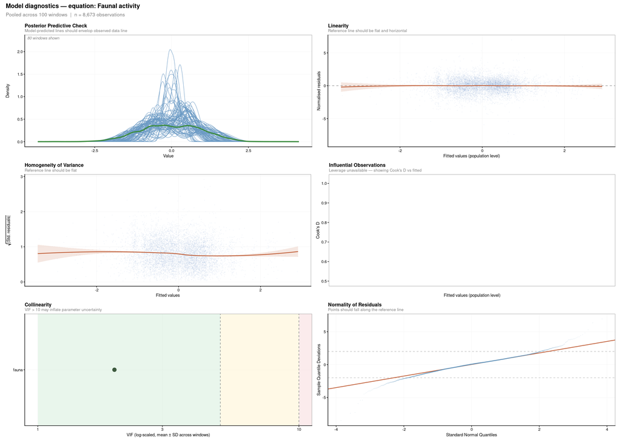

Figure 4: Six-panel model assumption diagnostics for each SEM equation under the selected configuration (window duration and transformation from model_parameters.txt, diagnostically valid windows only). Rows: P1-P2 (distributional fit and linearity), P3-P4 (variance homogeneity and influence), P5-P6 (collinearity and residual normality). See function documentation for panel-by-panel interpretation guidance.

## 6. Export